# ReneWind

Renewable energy sources play an increasingly important role in the global energy mix, as the effort to reduce the environmental impact of energy production increases.

Out of all the renewable energy alternatives, wind energy is one of the most developed technologies worldwide. The U.S Department of Energy has put together a guide to achieving operational efficiency using predictive maintenance practices.

Predictive maintenance uses sensor information and analysis methods to measure and predict degradation and future component capability. The idea behind predictive maintenance is that failure patterns are predictable and if component failure can be predicted accurately and the component is replaced before it fails, the costs of operation and maintenance will be much lower.

The sensors fitted across different machines involved in the process of energy generation collect data related to various environmental factors (temperature, humidity, wind speed, etc.) and additional features related to various parts of the wind turbine (gearbox, tower, blades, break, etc.).

## Objective

“ReneWind” is a company working on improving the machinery/processes involved in the production of wind energy using machine learning and has collected data of generator failure of wind turbines using sensors. They have shared a ciphered version of the data, as the data collected through sensors is confidential (the type of data collected varies with companies). Data has 40 predictors, 40000 observations in the training set and 10000 in the test set.

The objective is to build various classification models, tune them and find the best one that will help identify failures so that the generator could be repaired before failing/breaking and the overall maintenance cost of the generators can be brought down.

“1” in the target variables should be considered as “failure” and “0” will represent “No failure”.

The nature of predictions made by the classification model will translate as follows:

- True positives (TP) are failures correctly predicted by the model.
- False negatives (FN) are real failures in a wind turbine where there is no detection by model.
- False positives (FP) are detections in a wind turbine where there is no failure.

So, the maintenance cost associated with the model would be:

**Maintenance cost** = `TP*(Repair cost) + FN*(Replacement cost) + FP*(Inspection cost)` where,

- `Replacement cost = $40,000`
- `Repair cost = $15,000`
- `Inspection cost = $5,000`

Here the objective is to reduce the maintenance cost so, we want a metric that could reduce the maintenance cost.

- The minimum possible maintenance cost = `Actual failures*(Repair cost) = (TP + FN)*(Repair cost)`
- The maintenance cost associated with model = `TP*(Repair cost) + FN*(Replacement cost) + FP*(Inspection cost)`

So, we will try to maximize the ratio of minimum possible maintenance cost and the maintenance cost associated with the model.

The value of this ratio will lie between 0 and 1, the ratio will be 1 only when the maintenance cost associated with the model will be equal to the minimum possible maintenance cost.

## Data Description

- The data provided is a transformed version of original data which was collected using sensors.
- Train.csv - To be used for training and tuning of models.
- Test.csv - To be used only for testing the performance of the final best model.
- Both the datasets consist of 40 predictor variables and 1 target variable

## Importing libraries

```python
# To help with reading and manipulating data
import pandas as pd
import numpy as np

# To help with data visualization
%matplotlib inline
import matplotlib.pyplot as plt
import seaborn as sns

# To be used for missing value imputation
from sklearn.impute import SimpleImputer

# To help with model building
from sklearn.linear_model import LogisticRegression
from sklearn.tree import DecisionTreeClassifier
from sklearn.ensemble import (
    AdaBoostClassifier,
    GradientBoostingClassifier,
    RandomForestClassifier,
    BaggingClassifier,
)
from xgboost import XGBClassifier

# To get different metric scores, and split data
from sklearn import metrics
from sklearn.model_selection import train_test_split, StratifiedKFold, cross_val_score
from sklearn.metrics import (
    f1_score,
    accuracy_score,
    recall_score,
    precision_score,
    confusion_matrix,
    roc_auc_score,
    plot_confusion_matrix,
)

# To be used for data scaling and one hot encoding
from sklearn.preprocessing import StandardScaler, MinMaxScaler, OneHotEncoder

# To be used for tuning the model
from sklearn.model_selection import GridSearchCV, RandomizedSearchCV

# To be used for creating pipelines and personalizing them
from sklearn.pipeline import Pipeline
from sklearn.compose import ColumnTransformer

# To define maximum number of columns to be displayed in a dataframe
pd.set_option("display.max_columns", None)

# To supress scientific notations for a dataframe
pd.set_option("display.float_format", lambda x: "%.3f" % x)

# To oversample and undersample data
from imblearn.over_sampling import SMOTE
from imblearn.under_sampling import RandomUnderSampler

# To supress warnings
import warnings

warnings.filterwarnings("ignore")

# This will help in making the Python code more structured automatically (good coding practice)
%load_ext nb_black
```

## Loading Data

```python
trdata = pd.read_csv("Train.csv")
```

```python
# copying data to another varaible to avoid any changes to original data
data = trdata.copy()
```

## Data Overview

### View the first and last 5 rows of the dataset.

```python
# let's view the first 5 rows of the data
data.head()
```

|  | V1 | V2 | V3 | V4 | V5 | V6 | V7 | V8 | V9 | V10 | V11 | V12 | V13 | V14 | V15 | V16 | V17 | V18 | V19 | V20 | V21 | V22 | V23 | V24 | V25 | V26 | V27 | V28 | V29 | … |
| --- | --- | --- | --- | --- | --- | --- | --- | --- | --- | --- | --- | --- | --- | --- | --- | --- | --- | --- | --- | --- | --- | --- | --- | --- | --- | --- | --- | --- | --- | --- |
| 0 | -4.465 | -4.679 | 3.102 | 0.506 | -0.221 | -2.033 | -2.911 | 0.051 | -1.522 | 3.762 | -5.715 | 0.736 | 0.981 | 1.418 | -3.376 | -3.047 | 0.306 | 2.914 | 2.270 | 4.395 | -2.388 | 0.646 | -1.191 | 3.133 | 0.665 | -2.511 | -0.037 | 0.726 | -3.982 | … |
| 1 | -2.910 | -2.569 | 4.109 | 1.317 | -1.621 | -3.827 | -1.617 | 0.669 | 0.387 | 0.854 | -6.353 | 4.272 | 3.162 | 0.258 | -3.547 | -4.285 | 2.897 | 1.508 | 3.668 | 7.124 | -4.096 | 1.015 | -0.970 | -0.968 | 2.064 | -1.646 | 0.427 | 0.735 | -4.470 | … |
| 2 | 4.284 | 5.105 | 6.092 | 2.640 | -1.041 | 1.308 | -1.876 | -9.582 | 3.470 | 0.763 | -2.573 | -3.350 | -0.595 | -5.247 | -4.310 | -16.232 | -1.000 | 2.318 | 5.942 | -3.858 | -11.599 | 4.021 | -6.281 | 4.633 | 0.930 | 6.280 | 0.851 | 0.269 | -2.206 | … |
| 3 | 3.366 | 3.653 | 0.910 | -1.368 | 0.332 | 2.359 | 0.733 | -4.332 | 0.566 | -0.101 | 1.914 | -0.951 | -1.255 | -2.707 | 0.193 | -4.769 | -2.205 | 0.908 | 0.757 | -5.834 | -3.065 | 1.597 | -1.757 | 1.766 | -0.267 | 3.625 | 1.500 | -0.586 | 0.783 | … |
| 4 | -3.832 | -5.824 | 0.634 | -2.419 | -1.774 | 1.017 | -2.099 | -3.173 | -2.082 | 5.393 | -0.771 | 1.107 | 1.144 | 0.943 | -3.164 | -4.248 | -4.039 | 3.689 | 3.311 | 1.059 | -2.143 | 1.650 | -1.661 | 1.680 | -0.451 | -4.551 | 3.739 | 1.134 | -2.034 | … |

```python
# let's view the last 5 rows of the data
data.tail()
```

|  | V1 | V2 | V3 | V4 | V5 | V6 | V7 | V8 | V9 | V10 | V11 | V12 | V13 | V14 | V15 | V16 | V17 | V18 | V19 | V20 | V21 | V22 | V23 | V24 | V25 | V26 | V27 | V28 | V29 | … |
| --- | --- | --- | --- | --- | --- | --- | --- | --- | --- | --- | --- | --- | --- | --- | --- | --- | --- | --- | --- | --- | --- | --- | --- | --- | --- | --- | --- | --- | --- | --- |
| 39995 | -3.897 | -3.942 | -0.351 | -2.417 | 1.108 | -1.528 | -3.520 | 2.055 | -0.234 | -0.358 | -3.782 | 2.180 | 6.112 | 1.985 | -8.330 | -1.639 | -0.915 | 5.672 | -3.924 | 2.133 | -4.502 | 2.777 | 5.728 | 1.620 | -1.700 | -0.042 | -2.923 | -2.760 | -2.254 | … |
| 39996 | -3.187 | -10.052 | 5.696 | -4.370 | -5.355 | -1.873 | -3.947 | 0.679 | -2.389 | 5.457 | 1.583 | 3.571 | 9.227 | 2.554 | -7.039 | -0.994 | -9.665 | 1.155 | 3.877 | 3.524 | -7.015 | -0.132 | -3.446 | -4.801 | -0.876 | -3.812 | 5.422 | -3.732 | 0.609 | … |
| 39997 | -2.687 | 1.961 | 6.137 | 2.600 | 2.657 | -4.291 | -2.344 | 0.974 | -1.027 | 0.497 | -9.589 | 3.177 | 1.055 | -1.416 | -4.669 | -5.405 | 3.720 | 2.893 | 2.329 | 1.458 | -6.429 | 1.818 | 0.806 | 7.786 | 0.331 | 5.257 | -4.867 | -0.819 | -5.667 | … |
| 39998 | 0.521 | 0.096 | 8.457 | 2.138 | -1.636 | -2.713 | -2.693 | -3.410 | 1.936 | 2.012 | -4.989 | -0.819 | 4.166 | -1.192 | -5.033 | -8.523 | -1.950 | 0.017 | 4.505 | 2.031 | -8.849 | 0.566 | -6.040 | -0.043 | 1.656 | 4.250 | 1.727 | -1.686 | -3.963 | … |
| 39999 | 2.403 | -1.336 | 6.451 | -5.356 | -0.434 | 0.255 | -1.120 | -2.523 | -0.654 | 2.316 | -2.862 | 0.199 | 1.593 | -0.337 | -0.709 | -4.408 | -3.683 | 2.973 | -1.223 | -1.958 | -4.454 | 0.464 | -4.952 | -1.624 | 2.965 | 2.009 | 5.712 | -2.910 | -2.287 | … |

### Understand the shape of the dataset

```python
data.shape
```

```
(40000, 41)
```

### Check the data types of the columns for the dataset

```python
data.info()
```

```
<class 'pandas.core.frame.DataFrame'>
RangeIndex: 40000 entries, 0 to 39999
Data columns (total 41 columns):
 #   Column  Non-Null Count  Dtype
---  ------  --------------  -----
 0   V1      39954 non-null  float64
 1   V2      39961 non-null  float64
 2   V3      40000 non-null  float64
 3   V4      40000 non-null  float64
 4   V5      40000 non-null  float64
 5   V6      40000 non-null  float64
 6   V7      40000 non-null  float64
 7   V8      40000 non-null  float64
 8   V9      40000 non-null  float64
 9   V10     40000 non-null  float64
```

[output cut: 33 more lines]

**Observations**

- There are a total of 41 columns and 40000 observations in the dataset
- We can see that V1 and V2 column have less than 40000 non-null values i.e. column have missing values. We'll explore this further.
- The data type of the 40 predictors are type float and the target variable is of type int.

### Let's check the duplicate data. And if any, we should remove it.

```python
data.duplicated().sum()
```

```
0
```

- There are no duplicate values in the dataset.

### Check for missing values

```python
data.isnull().sum()
```

```
V1        46
V2        39
V3         0
V4         0
V5         0
V6         0
V7         0
V8         0
V9         0
V10        0
V11        0
V12        0
V13        0
V14        0
V15        0
V16        0
V17        0
V18        0
V19        0
V20        0
V21        0
V22        0
V23        0
V24        0
V25        0
V26        0
V27        0
V28        0
V29        0
V30        0
V31        0
V32        0
V33        0
V34        0
V35        0
V36        0
V37        0
V38        0
V39        0
V40        0
Target     0
dtype: int64
```

- Coulmns V1 and V2 have 46 and 39 missing values respectively.

### Summary of the dataset

```python
data.describe().T
```

|  | count | mean | std | min | 25% | 50% | 75% | max |
| --- | --- | --- | --- | --- | --- | --- | --- | --- |
| V1 | 39954.000 | -0.288 | 3.449 | -13.502 | -2.751 | -0.774 | 1.837 | 17.437 |
| V2 | 39961.000 | 0.443 | 3.139 | -13.212 | -1.638 | 0.464 | 2.538 | 13.089 |
| V3 | 40000.000 | 2.506 | 3.406 | -11.469 | 0.203 | 2.265 | 4.585 | 18.366 |
| V4 | 40000.000 | -0.066 | 3.437 | -16.015 | -2.350 | -0.124 | 2.149 | 13.280 |
| V5 | 40000.000 | -0.045 | 2.107 | -8.613 | -1.507 | -0.097 | 1.346 | 9.403 |
| V6 | 40000.000 | -1.001 | 2.037 | -10.227 | -2.363 | -1.007 | 0.374 | 7.065 |
| V7 | 40000.000 | -0.893 | 1.757 | -8.206 | -2.037 | -0.935 | 0.207 | 8.006 |
| V8 | 40000.000 | -0.563 | 3.299 | -15.658 | -2.660 | -0.384 | 1.714 | 11.679 |
| V9 | 40000.000 | -0.008 | 2.162 | -8.596 | -1.494 | -0.052 | 1.426 | 8.507 |
| V10 | 40000.000 | -0.002 | 2.183 | -11.001 | -1.391 | 0.106 | 1.486 | 8.108 |
| V11 | 40000.000 | -1.918 | 3.116 | -14.832 | -3.941 | -1.942 | 0.089 | 13.852 |
| V12 | 40000.000 | 1.578 | 2.915 | -13.619 | -0.431 | 1.485 | 3.541 | 15.754 |
| V13 | 40000.000 | 1.591 | 2.865 | -13.830 | -0.209 | 1.654 | 3.476 | 15.420 |
| V14 | 40000.000 | -0.947 | 1.788 | -8.309 | -2.165 | -0.957 | 0.266 | 6.213 |
| V15 | 40000.000 | -2.436 | 3.341 | -17.202 | -4.451 | -2.399 | -0.382 | 12.875 |
| V16 | 40000.000 | -2.943 | 4.212 | -21.919 | -5.632 | -2.719 | -0.113 | 13.583 |
| V17 | 40000.000 | -0.143 | 3.344 | -17.634 | -2.227 | -0.028 | 2.072 | 17.405 |
| V18 | 40000.000 | 1.189 | 2.586 | -11.644 | -0.403 | 0.867 | 2.564 | 13.180 |
| V19 | 40000.000 | 1.181 | 3.395 | -13.492 | -1.051 | 1.278 | 3.497 | 16.059 |
| V20 | 40000.000 | 0.027 | 3.675 | -13.923 | -2.434 | 0.030 | 2.513 | 16.052 |
| V21 | 40000.000 | -3.621 | 3.557 | -19.436 | -5.921 | -3.559 | -1.284 | 13.840 |
| V22 | 40000.000 | 0.943 | 1.646 | -10.122 | -0.112 | 0.963 | 2.018 | 7.410 |
| V23 | 40000.000 | -0.388 | 4.052 | -16.188 | -3.119 | -0.275 | 2.438 | 15.080 |
| V24 | 40000.000 | 1.142 | 3.913 | -18.488 | -1.483 | 0.964 | 3.563 | 19.769 |
| V25 | 40000.000 | -0.003 | 2.025 | -8.228 | -1.373 | 0.021 | 1.400 | 8.223 |
| V26 | 40000.000 | 1.896 | 3.421 | -12.588 | -0.319 | 1.964 | 4.163 | 16.836 |
| V27 | 40000.000 | -0.617 | 4.392 | -14.905 | -3.692 | -0.910 | 2.201 | 21.595 |
| V28 | 40000.000 | -0.888 | 1.925 | -9.685 | -2.193 | -0.905 | 0.377 | 6.907 |
| V29 | 40000.000 | -1.005 | 2.676 | -12.579 | -2.799 | -1.206 | 0.604 | 11.852 |
| V30 | 40000.000 | -0.033 | 3.031 | -14.796 | -1.908 | 0.185 | 2.040 | 13.191 |
| V31 | 40000.000 | 0.506 | 3.483 | -19.377 | -1.799 | 0.491 | 2.778 | 17.255 |
| V32 | 40000.000 | 0.327 | 5.499 | -23.201 | -3.392 | 0.056 | 3.789 | 24.848 |
| V33 | 40000.000 | 0.057 | 3.574 | -17.454 | -2.238 | -0.050 | 2.256 | 16.692 |
| V34 | 40000.000 | -0.464 | 3.186 | -17.985 | -2.128 | -0.251 | 1.433 | 14.358 |
| V35 | 40000.000 | 2.235 | 2.924 | -15.350 | 0.332 | 2.110 | 4.045 | 16.805 |
| V36 | 40000.000 | 1.530 | 3.820 | -17.479 | -0.937 | 1.572 | 3.997 | 19.330 |
| V37 | 40000.000 | -0.000 | 1.778 | -7.640 | -1.266 | -0.133 | 1.161 | 7.803 |
| V38 | 40000.000 | -0.351 | 3.964 | -17.375 | -3.017 | -0.319 | 2.291 | 15.964 |
| V39 | 40000.000 | 0.900 | 1.751 | -7.136 | -0.262 | 0.921 | 2.069 | 7.998 |
| V40 | 40000.000 | -0.897 | 2.998 | -11.930 | -2.950 | -0.949 | 1.092 | 10.654 |
| Target | 40000.000 | 0.055 | 0.227 | 0.000 | 0.000 | 0.000 | 0.000 | 1.000 |

- Target has only two values 0 and 1.
- The values of all the predictor variables are between -23.201 to 24.848.

## EDA and insights

### Univariate analysis

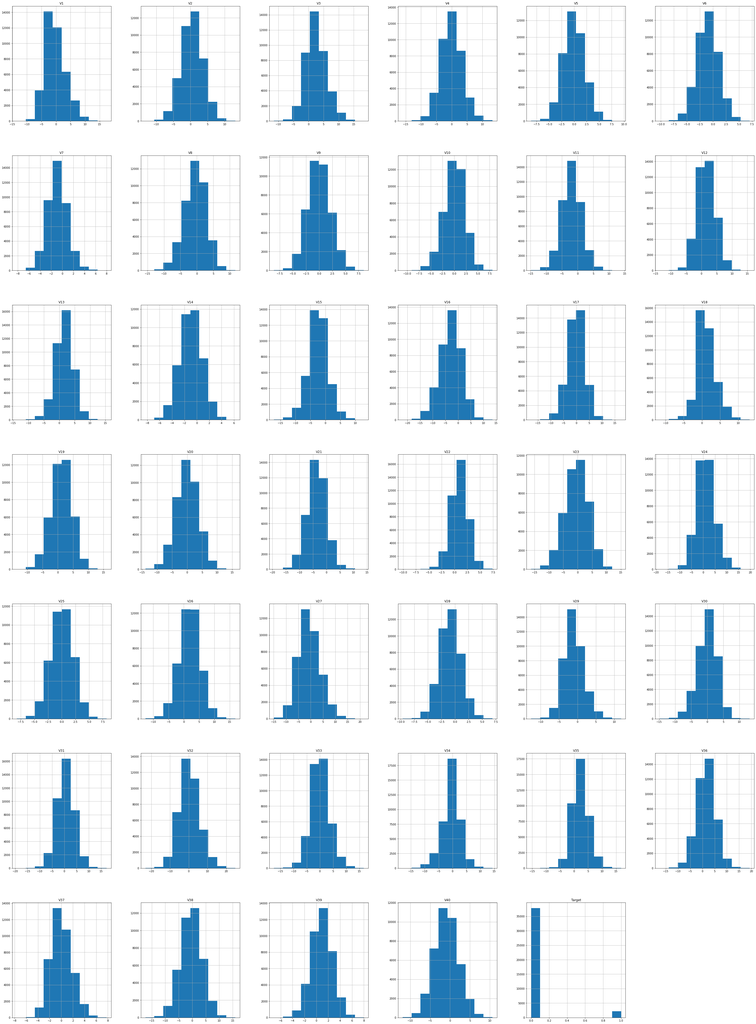

```python
# Histogram to plot all the columns
data.hist(bins=None, figsize=(50, 70))
plt.show()
```

**Observations**